# Practical Machine Learning - Course Project

Giovanna14

22/03/2015

## Synopsis

This project is based on the Weight Lifting Exercise Dataset available at http://groupware.les.inf.puc-rio.br/har. The dataset is part of a human activity recognition research making use of wearable accelerometers to determine how well a given activity is performed and automatically detect execution mistakes. The goal of this project is to to use this dataset to build a machine learning algorithm that predicts the manner in which the participants executed the exercise.

## Dataset

Data were collected from accelerometers on the belt, forearm, arm, and dumbbell of 6 people, while they were lifting a dumbbell in 5 different ways, a correct one and 4 different wrong ways, simulating typical mistakes. The variable `classe` in the dataset defines the way how the exercise was performed. It takes up 5 possible values, A for correct excution and B, C, D, E for each of the 4 simulated execution mistakes.

```r
#downloading data
URL1 <- "https://d396qusza40orc.cloudfront.net/predmachlearn/pml-training.csv"
URL2 <- "https://d396qusza40orc.cloudfront.net/predmachlearn/pml-testing.csv"
file1 <- "pml-training.csv"
file2 <- "pml-testing.csv"
if (!file.exists(file1)){download.file(URL1,file1,method="curl")}
if (!file.exists(file2)){download.file(URL2,file2,method="curl")}
```

A preliminary inspection of the pml-training.csv file shows the presence of several variables whose values are almost only NAs, blank values, or “#DIV/0!”. So while loading the data into data frames we redifine all these values as NAs.

```r
training <- read.csv(file1,na.strings=c("NA","","#DIV/0!"))
testing <- read.csv(file2,na.strings=c("NA","","#DIV/0!"))
```

## Preparatory steps

For our purposes we use the `caret` package, so we load this and other additional packages that are required subsequently for modelling and plotting purposes.

```r
library(ggplot2);library(lattice);library(caret)
library(parallel); library(doParallel) #for parallel processing
library(AppliedPredictiveModeling)
library(randomForest);library(rpart);library(partykit)
```

Since there is a large number of observations, we can split the provided training set into three subsets, a training, a validation, and a testing set approximately comprising 60%, 20%, and 20% of the original set, respectively. Since there are several columns that contains almost only NAs, implementing an imputing strategy for these columns does not seem appropriate, hence we discard them from our newly created training set. In so doing, we are automatically discarding the columns containing computed statistical quantities (e.g. mean, kurtosis, skewness), with the exception of total accelerations.  
We also discard the first 7 columns that do not contain useful information for the purpose of modelling (sequential numbers, names of participants, time stamps, windows for measurement collection).

```r
## split original training set into a training, a validation and
## a test set
set.seed(1521)
inTrain <- createDataPartition(y=training$classe,p=0.6,list=FALSE)
trainset <- training[inTrain,]
notrain <- training[-inTrain,]
inVal <- createDataPartition(y=notrain$classe,p=0.5,list=FALSE)
validset <- notrain[inVal,]
testset <- notrain[-inVal,]
# remove first 7 columns that are not useful for modelling
trainset <- trainset[,-c(1:7)]
# remove columns with NAs
trainset <- trainset[,colSums(is.na(trainset))==0]
dim(trainset)
```

```
## [1] 11776    53
```

## Exploratory analysis

We carry out some exploratory analysis on the training set to identify possible trends and outliers.

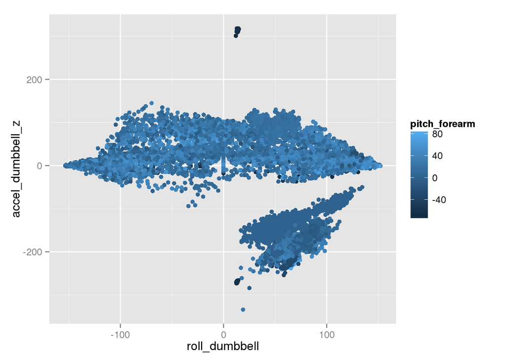

```r
#featurePlot(x=trainset[,c("roll_belt","pitch_forearm",
#                          "roll_dumbbell","roll_forearm",
#                          "accel_dumbbell_z")],y=trainset$classe,
#            plot="pairs")
qplot(roll_dumbbell,accel_dumbbell_z,colour=pitch_forearm,data=trainset)
```

There are some outliers, and one would have to investigate them. However, in the following we proceed without any data processing.

## Building predictive models

In the following we use `train` from the `caret` package to build predictive models with different subsets of predictors and with two alternative models, i.e. the tree-based model `rpart` and the random forest model `rf`.

### Tree-based models

We create an rpart model with all predictors in the cleaned training set.

```r
set.seed(3528)
registerDoParallel(clust <- makeForkCluster(3))
fit1_rpart <- train(classe ~ ., data=trainset,method="rpart",
            trControl=trainControl(method="cv",number=5,
                                     allowParallel=TRUE)
            )
stopCluster(clust)
fit1_rpart$finalModel
```

```
## n= 11776
##
## node), split, n, loss, yval, (yprob)
##       * denotes terminal node
##
##  1) root 11776 8428 A (0.28 0.19 0.17 0.16 0.18)
##    2) roll_belt< 129.5 10713 7405 A (0.31 0.21 0.19 0.18 0.11)
##      4) pitch_forearm< -34.35 975    4 A (1 0.0041 0 0 0) *
##      5) pitch_forearm>=-34.35 9738 7401 A (0.24 0.23 0.21 0.2 0.12)
##       10) magnet_dumbbell_y< 436.5 8178 5896 A (0.28 0.18 0.24 0.19 0.1)
##         20) roll_forearm< 123.5 5055 3021 A (0.4 0.18 0.19 0.17 0.057) *
##         21) roll_forearm>=123.5 3123 2088 C (0.079 0.19 0.33 0.22 0.18) *
##       11) magnet_dumbbell_y>=436.5 1560  770 B (0.035 0.51 0.038 0.23 0.19) *
##    3) roll_belt>=129.5 1063   40 E (0.038 0 0 0 0.96) *
```

```r
# importance of variables
varImp(fit1_rpart)
```

```
## rpart variable importance
##
##   only 20 most important variables shown (out of 52)
##
##                   Overall
## pitch_forearm      100.00
## roll_belt           67.79
## roll_forearm        67.17
## magnet_dumbbell_y   48.45
## accel_belt_z        41.07
## yaw_belt            40.02
## magnet_belt_y       38.67
## magnet_dumbbell_z   36.30
## total_accel_belt    33.68
## magnet_arm_x        26.85
## accel_arm_x         25.23
## roll_dumbbell       18.45
## accel_dumbbell_y    14.54
## roll_arm            14.29
## magnet_arm_z         0.00
## pitch_belt           0.00
## accel_arm_z          0.00
## gyros_dumbbell_x     0.00
## accel_dumbbell_z     0.00
## gyros_dumbbell_y     0.00
```

The resulting classification tree is shown in Figure 1.

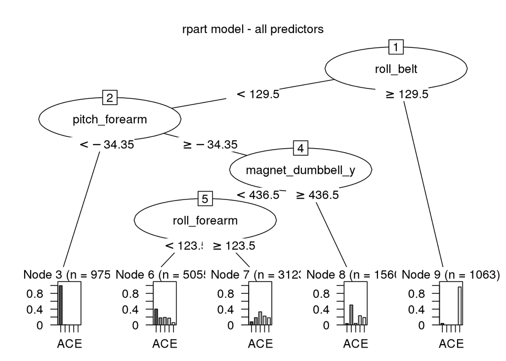

```r
fit1party <- as.party(fit1_rpart$finalModel)
plot(fit1party,main="rpart model - all predictors")
```

**Figure1.** Model trees obtained using an rpart model with all predictors.

### Random forest models

For random forest models we first use all predictors in the cleaned training set and then we try to progressively reduce the number of predictors.

```r
# use parallel processing on 3 CPUs to train with random forest with all predictors
set.seed(3528)
registerDoParallel(clust <- makeForkCluster(3))
fit1_rf <- train(classe ~ ., data=trainset,method="rf",ntree=200,
            trControl=trainControl(method="cv",number=5,
                                     allowParallel=TRUE)
            )
stopCluster(clust)
fit1_rf$finalModel
```

```
##
## Call:
##  randomForest(x = x, y = y, ntree = 200, mtry = param$mtry)
##                Type of random forest: classification
##                      Number of trees: 200
## No. of variables tried at each split: 27
##
##         OOB estimate of  error rate: 0.87%
## Confusion matrix:
##      A    B    C    D    E class.error
## A 3343    5    0    0    0 0.001493429
## B   21 2247   10    1    0 0.014041246
## C    0   17 2027   10    0 0.013145083
## D    0    0   21 1907    2 0.011917098
## E    1    4    5    6 2149 0.007390300
```

```r
# importance of predictors
imp1_rf <- varImp(fit1_rf)
varImp(fit1_rf)
```

```
## rf variable importance
##
##   only 20 most important variables shown (out of 52)
##
##                      Overall
## roll_belt            100.000
## pitch_forearm         62.065
## yaw_belt              57.287
## magnet_dumbbell_y     44.190
## magnet_dumbbell_z     43.747
## pitch_belt            42.844
## roll_forearm          38.782
## accel_dumbbell_y      20.699
## magnet_belt_z         17.426
## accel_forearm_x       16.745
## roll_dumbbell         16.404
## magnet_dumbbell_x     15.142
## total_accel_dumbbell  14.708
## accel_belt_z          14.271
## magnet_forearm_z      13.318
## accel_dumbbell_z      12.808
## magnet_belt_y         11.667
## yaw_arm               11.429
## magnet_belt_x         10.758
## gyros_belt_z           9.676
```

```r
# create a subset of the training set retaining only the most
# important predictors
mostImpVars1_rf <- rownames(imp1_rf$importance)[imp1_rf$importance>10]
subtrainset1_rf <- trainset[,c(mostImpVars1_rf,"classe")]
dim(subtrainset1_rf)
```

```
## [1] 11776    20
```

We now use only the most important predictors identified in the previous step.

```r
# use parallel processing to train with random forest
set.seed(3528)
registerDoParallel(clust <- makeForkCluster(3))
fit2_rf <- train(classe ~ ., data=subtrainset1_rf,method="rf",ntree=200,
            trControl=trainControl(method="cv",number=5,
                                     allowParallel=TRUE)
            )
stopCluster(clust)
fit2_rf$finalModel
```

```
##
## Call:
##  randomForest(x = x, y = y, ntree = 200, mtry = param$mtry)
##                Type of random forest: classification
##                      Number of trees: 200
## No. of variables tried at each split: 10
##
##         OOB estimate of  error rate: 1.29%
## Confusion matrix:
##      A    B    C    D    E class.error
## A 3335   11    1    1    0 0.003882915
## B   26 2227   23    3    0 0.022817025
## C    0   23 2015   15    1 0.018987342
## D    0    3   20 1903    4 0.013989637
## E    1    4    4   12 2144 0.009699769
```

```r
imp2_rf <- varImp(fit2_rf)
varImp(fit2_rf)
```

```
## rf variable importance
##
##                       Overall
## roll_belt            100.0000
## pitch_forearm         55.3918
## yaw_belt              53.3320
## pitch_belt            41.2528
## magnet_dumbbell_z     36.9868
## magnet_dumbbell_y     36.8777
## roll_forearm          32.2487
## magnet_forearm_z       8.5339
## accel_dumbbell_y       7.4398
## roll_dumbbell          7.2850
## accel_forearm_x        7.1738
## yaw_arm                6.3225
## magnet_belt_z          6.1489
## magnet_dumbbell_x      5.5135
## accel_dumbbell_z       4.4308
## total_accel_dumbbell   2.9141
## accel_belt_z           1.5782
## magnet_belt_y          0.9423
## magnet_belt_x          0.0000
```

```r
# create a subset of the training set retaining only the most
# important predictors
mostImpVars2_rf <- rownames(imp2_rf$importance)[imp2_rf$importance>5]
subtrainset2_rf <- trainset[,c(mostImpVars2_rf,"classe")]
dim(subtrainset2_rf)
```

```
## [1] 11776    15
```

We further reduce the number of predictors, based on the most important predictors identified in the previous step.

```r
# use parallel processing to train with random forest
set.seed(3528)
registerDoParallel(clust <- makeForkCluster(3))
fit3_rf <- train(classe ~ ., data=subtrainset2_rf,method="rf",ntree=200,
            trControl=trainControl(method="cv",number=5,
                                     allowParallel=TRUE)
            )
stopCluster(clust)
fit3_rf$finalModel
```

[output not shown]

```r
imp3_rf <- varImp(fit3_rf)
varImp(fit3_rf)
```

```
## rf variable importance
##
##                   Overall
## roll_belt         100.000
## yaw_belt           66.016
## pitch_belt         46.870
## magnet_dumbbell_z  44.591
## pitch_forearm      39.816
## magnet_dumbbell_y  33.970
## roll_forearm       31.672
## magnet_belt_z      25.666
## magnet_dumbbell_x  22.613
## accel_dumbbell_y   15.576
## roll_dumbbell      10.341
## magnet_forearm_z    5.161
## accel_forearm_x     2.641
## yaw_arm             0.000
```

### Comparing and fine-tuning random forest models

Then we have a look at the random forest model error rates.

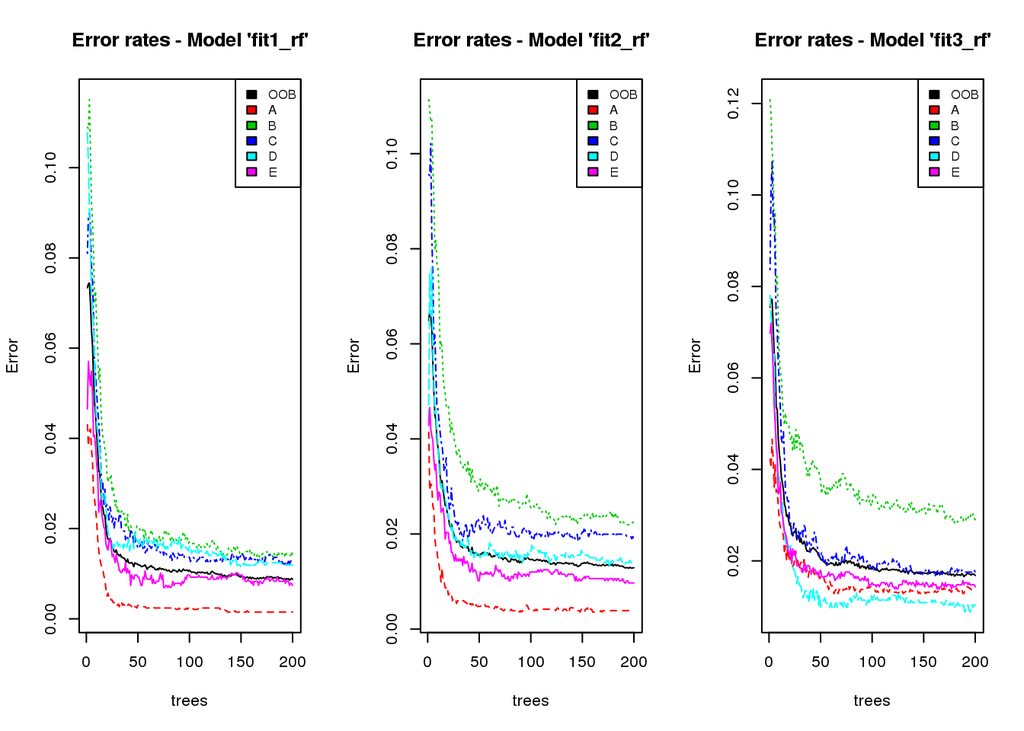

```r
par(mfrow=c(1,3))
plot(fit1_rf$finalModel,type="l",
     main="Error rates - Model 'fit1_rf'")
legend("topright",colnames(fit1_rf$finalModel$err.rate),
      col=1:6,cex=0.8,fill=1:6)
plot(fit2_rf$finalModel,type="l",
     main="Error rates - Model 'fit2_rf'")
legend("topright",colnames(fit2_rf$finalModel$err.rate),
      col=1:6,cex=0.8,fill=1:6)
plot(fit3_rf$finalModel,type="l",
     main="Error rates - Model 'fit3_rf'")
legend("topright",colnames(fit3_rf$finalModel$err.rate),
      col=1:6,cex=0.8,fill=1:6)
```

```r
par(mfcol=c(1,1))
```

**Figure 2.** Error rates for our three different rf models as a function of the number of trees.

We apply the different models to the validation set and look at the achieved accuracy, to choose our final model.

```r
# look at confusion matrices on validation set
predfit1_rp_valid <- predict(fit1_rpart,validset)
predfit1_rf_valid <- predict(fit1_rf,validset)
predfit2_rf_valid <- predict(fit2_rf,validset)
predfit3_rf_valid <- predict(fit3_rf,validset)
fit1_rp_CM <- confusionMatrix(predfit1_rp_valid,testset$classe)
fit1_rf_CM <- confusionMatrix(predfit1_rf_valid,testset$classe)
fit2_rf_CM <- confusionMatrix(predfit2_rf_valid,testset$classe)
fit3_rf_CM <- confusionMatrix(predfit3_rf_valid,testset$classe)
print(c("rpart model",fit1_rp_CM))
```

```
## [[1]]
## [1] "rpart model"
##
## $positive
## NULL
##
## $table
##           Reference
## Prediction    A    B    C    D    E
##          A 1004  318  297  268  105
##          B   18  252   28  110   79
##          C   80  189  359  265  195
##          D    0    0    0    0    0
##          E   14    0    0    0  342
##
## $overall
##       Accuracy          Kappa  AccuracyLower  AccuracyUpper   AccuracyNull
##   4.988529e-01   3.461864e-01   4.830851e-01   5.146225e-01   2.844762e-01
## AccuracyPValue  McnemarPValue
##  1.049929e-175            NaN
##
## $byClass
##          Sensitivity Specificity Pos Pred Value Neg Pred Value Prevalence
## Class: A   0.8996416   0.6480228      0.5040161      0.9419990  0.2844762
## Class: B   0.3320158   0.9257269      0.5174538      0.8524447  0.1934744
## Class: C   0.5248538   0.7749305      0.3299632      0.8853616  0.1743564
## Class: D   0.0000000   1.0000000            NaN      0.8360948  0.1639052
## Class: E   0.4743412   0.9956277      0.9606742      0.8937482  0.1837879
##          Detection Rate Detection Prevalence Balanced Accuracy
## Class: A     0.25592659           0.50777466         0.7738322
## Class: B     0.06423655           0.12413969         0.6288714
## Class: C     0.09151160           0.27733877         0.6498922
## Class: D     0.00000000           0.00000000         0.5000000
## Class: E     0.08717818           0.09074688         0.7349845
##
## $dots
## list()
```

```r
print(c("random forest model1",fit1_rf_CM))
```

```
## [[1]]
## [1] "random forest model1"
##
## $positive
## NULL
##
## $table
##           Reference
## Prediction    A    B    C    D    E
##          A 1111   10    0    0    1
##          B    5  749    4    1    2
##          C    0    0  676    8    0
##          D    0    0    4  631    1
##          E    0    0    0    3  717
##
## $overall
##       Accuracy          Kappa  AccuracyLower  AccuracyUpper   AccuracyNull
##      0.9900586      0.9874224      0.9864346      0.9929214      0.2844762
## AccuracyPValue  McnemarPValue
##      0.0000000            NaN
##
## $byClass
##          Sensitivity Specificity Pos Pred Value Neg Pred Value Prevalence
## Class: A   0.9955197   0.9960812      0.9901961      0.9982149  0.2844762
## Class: B   0.9868248   0.9962073      0.9842313      0.9968374  0.1934744
## Class: C   0.9883041   0.9975301      0.9883041      0.9975301  0.1743564
## Class: D   0.9813375   0.9984756      0.9921384      0.9963493  0.1639052
## Class: E   0.9944521   0.9990631      0.9958333      0.9987512  0.1837879
##          Detection Rate Detection Prevalence Balanced Accuracy
## Class: A      0.2832016            0.2860056         0.9958005
## Class: B      0.1909253            0.1939842         0.9915161
## Class: C      0.1723171            0.1743564         0.9929171
## Class: D      0.1608463            0.1621208         0.9899065
## Class: E      0.1827683            0.1835330         0.9967576
##
## $dots
## list()
```

```r
print(c("random forest model 2",fit2_rf_CM))
```

```
## [[1]]
## [1] "random forest model 2"
##
## $positive
## NULL
##
## $table
##           Reference
## Prediction    A    B    C    D    E
##          A 1113    7    0    0    0
##          B    3  749    5    3    5
##          C    0    2  674    6    4
##          D    0    1    5  631    1
##          E    0    0    0    3  711
##
## $overall
##       Accuracy          Kappa  AccuracyLower  AccuracyUpper   AccuracyNull
##      0.9885292      0.9854884      0.9846810      0.9916211      0.2844762
## AccuracyPValue  McnemarPValue
##      0.0000000            NaN
##
## $byClass
##          Sensitivity Specificity Pos Pred Value Neg Pred Value Prevalence
## Class: A   0.9973118   0.9975062      0.9937500      0.9989297  0.2844762
## Class: B   0.9868248   0.9949431      0.9790850      0.9968334  0.1934744
## Class: C   0.9853801   0.9962952      0.9825073      0.9969107  0.1743564
## Class: D   0.9813375   0.9978659      0.9890282      0.9963470  0.1639052
## Class: E   0.9861304   0.9990631      0.9957983      0.9968838  0.1837879
##          Detection Rate Detection Prevalence Balanced Accuracy
## Class: A      0.2837114            0.2854958         0.9974090
## Class: B      0.1909253            0.1950038         0.9908839
## Class: C      0.1718073            0.1748662         0.9908376
## Class: D      0.1608463            0.1626306         0.9896017
## Class: E      0.1812388            0.1820036         0.9925967
##
## $dots
## list()
```

```r
print(c("random forest model 3",fit3_rf_CM))
```

```
## [[1]]
## [1] "random forest model 3"
##
## $positive
## NULL
##
## $table
##           Reference
## Prediction    A    B    C    D    E
##          A 1095   11    1    0    1
##          B   13  735    9    4    6
##          C    7    9  665    4    1
##          D    1    3    7  632    1
##          E    0    1    2    3  712
##
## $overall
##       Accuracy          Kappa  AccuracyLower  AccuracyUpper   AccuracyNull
##      0.9785878      0.9729232      0.9735581      0.9828857      0.2844762
## AccuracyPValue  McnemarPValue
##      0.0000000      0.2509987
##
## $byClass
##          Sensitivity Specificity Pos Pred Value Neg Pred Value Prevalence
## Class: A   0.9811828   0.9953687      0.9882671      0.9925400  0.2844762
## Class: B   0.9683794   0.9898862      0.9582790      0.9923954  0.1934744
## Class: C   0.9722222   0.9935165      0.9693878      0.9941304  0.1743564
## Class: D   0.9828927   0.9963415      0.9813665      0.9966453  0.1639052
## Class: E   0.9875173   0.9981262      0.9916435      0.9971919  0.1837879
##          Detection Rate Detection Prevalence Balanced Accuracy
## Class: A      0.2791231            0.2824369         0.9882758
## Class: B      0.1873566            0.1955136         0.9791328
## Class: C      0.1695131            0.1748662         0.9828694
## Class: D      0.1611012            0.1641601         0.9896171
## Class: E      0.1814938            0.1830232         0.9928218
##
## $dots
## list()
```

The rpart model has very low accuracy and we do not consider it any further. The accuracy of the random forest models decreases when reducing the number of predictors, but with 14 predictors still has $\sim$ 98% accuracy, as evaluated on the validation set. although with an increased error rate for `classe` = B. We feel that we can retain this last model, that is slightly less accurate but simpler than the one which uses all predictors and reduces the risk of overfitting.

## Final model

Based on the results from the use of the validation set we choose as our final model `fit3_rf`. This was obtained with the random forest method with 200 trees and 5-folds cross-validation by using the 14 predictors that were identified as the most important ones.

We apply this final model to our test set to evaluate the out-of-sample error.

```r
predfit3_rf_test <- predict(fit3_rf,testset)
confusionMatrix(predfit3_rf_test,testset$classe)
```

```
## Confusion Matrix and Statistics
##
##           Reference
## Prediction    A    B    C    D    E
##          A 1111    5    0    0    0
##          B    2  748    9    0    3
##          C    1    5  670    7    2
##          D    1    1    5  635    0
##          E    1    0    0    1  716
##
## Overall Statistics
##
##                Accuracy : 0.989
##                  95% CI : (0.9853, 0.9921)
##     No Information Rate : 0.2845
##     P-Value [Acc > NIR] : <2e-16
##
##                   Kappa : 0.9861
##  Mcnemar's Test P-Value : 0.2373
##
## Statistics by Class:
##
##                      Class: A Class: B Class: C Class: D Class: E
## Sensitivity            0.9955   0.9855   0.9795   0.9876   0.9931
## Specificity            0.9982   0.9956   0.9954   0.9979   0.9994
## Pos Pred Value         0.9955   0.9816   0.9781   0.9891   0.9972
## Neg Pred Value         0.9982   0.9965   0.9957   0.9976   0.9984
## Prevalence             0.2845   0.1935   0.1744   0.1639   0.1838
## Detection Rate         0.2832   0.1907   0.1708   0.1619   0.1825
## Detection Prevalence   0.2845   0.1942   0.1746   0.1637   0.1830
## Balanced Accuracy      0.9969   0.9905   0.9875   0.9927   0.9962
```

Finally, we use our chosen model to make predictions on the provided testing dataset and save them to a text file for the submission part of this assignment.

```r
pred_final <- predict(fit3_rf,testing)
answers <- as.character(pred_final)
pml_write_files = function(x){
  n = length(x)
  for(i in 1:n){
    filename = paste0("problem_id_",i,".txt")
    write.table(x[i],file=filename,quote=FALSE,row.names=FALSE,col.names=FALSE)
  }
}
pml_write_files(answers)
```